# Estudis d'Informàtica, Multimedia i Telecomunicacions

# Mineria de dades: PEC2 - Mètodes no supervisats

Autor: Nom estudiant

Octubre 2023

# 1 Exercicis

Els exercicis es realitzaran sobre la base del joc de dades *Hawks* present en el paquet R *Stat2Data*.

Els estudiants i el professorat del Cornell College a Mount Vernon, Iowa, van recollir dades durant molts anys al mirador de falcons de l’estany MacBride, prop d’Iowa City, a l’estat d’Iowa. El joc de dades que analitzem aquí és un subconjunt del conjunt de dades original, utilitzant només aquelles espècies per a les que hi havia més de 10 observacions. Les dades es van recollir en mostres aleatòries de tres espècies diferents de falcons: Cua-roja, Esparver i Falcó de Cooper.

Hem seleccionat aquest joc de dades per la seva semblança amb el joc de dades *penguins* i pel seu potencial alhora d’aplicar-li algoritmes de mineria de dades no supervisats. Les variables numèriques en què us basareu són: *Wing*, *Weight*, *culmen*, *Hallux*

```r
if (!require('Stat2Data')) install.packages('Stat2Data'); library('Stat2Data')
data("Hawks")
summary(Hawks)
```

```
##      Month             Day             Year       CaptureTime   ReleaseTime
##  Min.   : 8.000   Min.   : 1.00   Min.   :1992   11:35  : 14          :842
##  1st Qu.: 9.000   1st Qu.: 9.00   1st Qu.:1995   13:30  : 14   11:00  :  2
##  Median :10.000   Median :16.00   Median :1999   11:45  : 13   11:35  :  2
##  Mean   : 9.843   Mean   :15.74   Mean   :1998   12:10  : 13   12:05  :  2
##  3rd Qu.:10.000   3rd Qu.:23.00   3rd Qu.:2001   14:00  : 13   12:50  :  2
##  Max.   :11.000   Max.   :31.00   Max.   :2003   13:05  : 12   13:32  :  2
##                                                  (Other):829   (Other): 56
##       BandNumber  Species  Age     Sex          Wing           Weight
##            :  2   CH: 70   A:224    :576   Min.   : 37.2   Min.   :  56.0
##  1142-09240:  1   RT:577   I:684   F:174   1st Qu.:202.0   1st Qu.: 185.0
##  1142-09241:  1   SS:261           M:158   Median :370.0   Median : 970.0
##  1142-09242:  1                            Mean   :315.6   Mean   : 772.1
##  1142-18229:  1                            3rd Qu.:390.0   3rd Qu.:1120.0
##  1142-19209:  1                            Max.   :480.0   Max.   :2030.0
##  (Other)   :901                            NA's   :1       NA's   :10
##      Culmen         Hallux            Tail        StandardTail
##  Min.   : 8.6   Min.   :  9.50   Min.   :119.0   Min.   :115.0
##  1st Qu.:12.8   1st Qu.: 15.10   1st Qu.:160.0   1st Qu.:162.0
##  Median :25.5   Median : 29.40   Median :214.0   Median :215.0
##  Mean   :21.8   Mean   : 26.41   Mean   :198.8   Mean   :199.2
##  3rd Qu.:27.3   3rd Qu.: 31.40   3rd Qu.:225.0   3rd Qu.:226.0
##  Max.   :39.2   Max.   :341.40   Max.   :288.0   Max.   :335.0
##  NA's   :7      NA's   :6                        NA's   :337
##      Tarsus        WingPitFat        KeelFat           Crop
##  Min.   :24.70   Min.   :0.0000   Min.   :0.000   Min.   :0.0000
##  1st Qu.:55.60   1st Qu.:0.0000   1st Qu.:2.000   1st Qu.:0.0000
##  Median :79.30   Median :1.0000   Median :2.000   Median :0.0000
##  Mean   :71.95   Mean   :0.7922   Mean   :2.184   Mean   :0.2345
##  3rd Qu.:87.00   3rd Qu.:1.0000   3rd Qu.:3.000   3rd Qu.:0.2500
##  Max.   :94.00   Max.   :3.0000   Max.   :4.000   Max.   :5.0000
##  NA's   :833     NA's   :831      NA's   :341     NA's   :343
```

## 1.1 Exercici 1

Presenta el joc de dades, nom i significat de cada columna, així com les distribucions dels seus valors.

Realitza un estudi aplicant el mètode K-means, similar al dels exemples 1.1 i 1.2

### 1.1.1 Resposta 1

Informació treta de la web oficial de R Package Documentation, Hawks (https://rdrr.io/rforge/Stat2Data/man/Hawks.html).

Les dades mostren valors mínims, màxims, mitjans i quartils per a cada columna. Al carregar les dades els valors no disponibles seran ignorats (*na.omit*)

Carreguem la llibreria necessària per a començar l’exercici

```r
if (!require('cluster')) install.packages('cluster')
library(cluster)
```

Carreguem les variables numèriques que farem servir en aquest exercici.

```r
x <- na.omit(Hawks[,c("Wing", "Weight", "Culmen", "Hallux")])
```

Si bé és lògic suposar que el nombre de clústers hauria de ser tres, farem proves amb diferents valors. Calculem les distàncies entre les observacions. A continuació provem diferents valors de número de clústers (de 2 a 10) i calculem la mitjana de la silueta per a cada mostra.

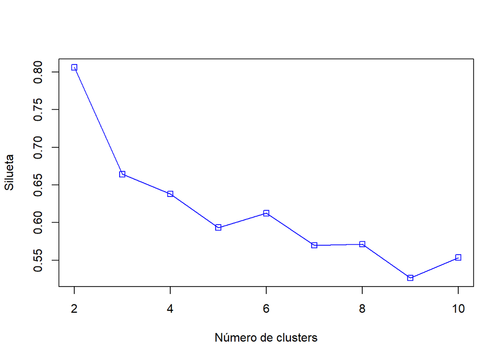

```r
d <- daisy(x)
resultados <- rep(0, 10)
for (i in c(2,3,4,5,6,7,8,9,10))
{
  fit           <- kmeans(x, i)
  y_cluster     <- fit$cluster
  sk            <- silhouette(y_cluster, d)
  resultados[i] <- mean(sk[,3])
}
plot(2:10,resultados[2:10],type="o",col="blue",pch=0,xlab="Número de clusters",ylab="Silueta")
```

El gràfic mostra que el valor màxim de la silueta es produeix amb 2 clústers, cosa que indica que aquest seria el millor valor, ja que les mostres estan més ben agrupades. Per a valors més grans la silueta disminueix, això ens indica que a mesura que anem afegint clústers, les mostres es tornen menys semblants dins dels seus respectius clústers.

Tot i que el gràfic ens diu que el millor valor és 2, al tindre un coneixement més gran de les dades amb les que treballem, utilitzar 3 clústers sembla una millor opció.

Podem utilitzar altres mètriques per a evaluar el millor nombre de clústers. A continuació farem servir l’anàlisi de la suma dels quadrats. Aquesta mètrica mesura la variabilitat de les dades dins de cada clúster. Un valor baix indica que les mostres són molt semblants entre elles, en canvi, un valor alt ens indica una major dispersió.

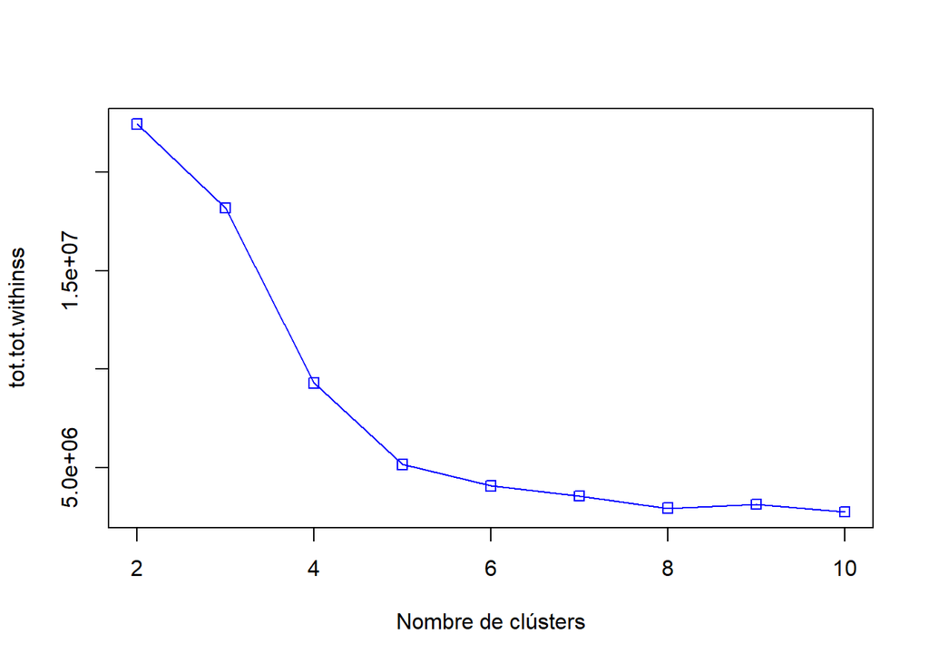

```r
resultados <- rep(0, 10)
for (i in c(2,3,4,5,6,7,8,9,10))
{
  fit           <- kmeans(x, i)
  resultados[i] <- fit$tot.withinss
}
plot(2:10,resultados[2:10],type="o",col="blue",pch=0,xlab="Nombre de clústers",ylab="tot.tot.withinss")
```

Si fem servir el mètode del colze al igual que en l’exemple guiat 1.2, observem al mirar la gràfica que el millor valor està en 4 o 5 clústers, que és quan la corba comença a estabilitzar-se.

Al igual que a l’exemple guiat, també farem servir la funció *kmeansruns* del paquet **fpc** que executarà l’algoritme kmeans com un conjunt de valors i seleccionarà el valor del número de clústers que millor funcioni d’acord amb els criteris seleccionats.

```r
if (!require('fpc')) install.packages('fpc'); library('fpc')
```

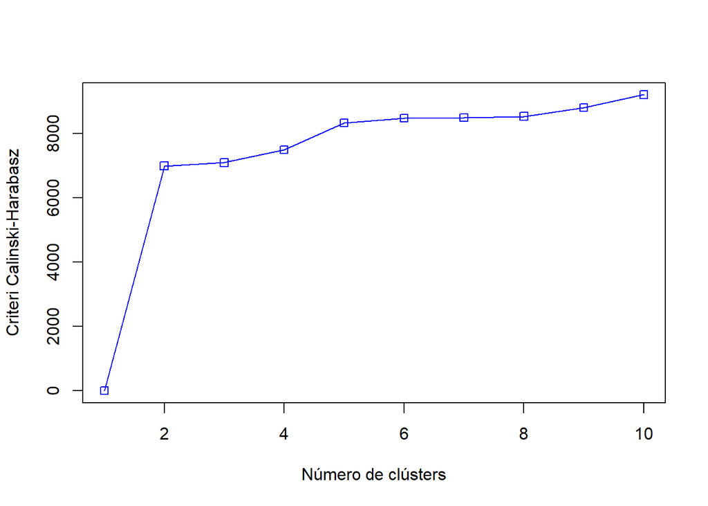

```r
fit_ch  <- kmeansruns(x, krange = 1:10, criterion = "ch")
plot(1:10,fit_ch$crit,type="o",col="blue",pch=0,xlab="Número de clústers",ylab="Criteri Calinski-Harabasz")
```

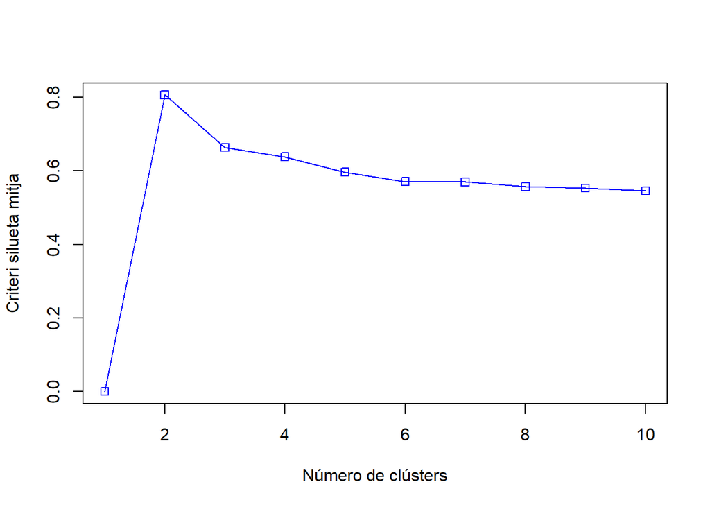

```r
fit_asw <- kmeansruns(x, krange = 1:10, criterion = "asw")
plot(1:10,fit_asw$crit,type="o",col="blue",pch=0,xlab="Número de clústers",ylab="Criteri silueta mitja")
```

Fent servir el criteri de la silueta mitjana, els valors elevats indiquen valors més òptims. Aquí també hi tenim un pic en 2 clústers. Seguidament la silueta disminueix lleugerament i es manté relativament estable. Aquest gràfic ens indica que 2 clústers és un bon nombre.

A part dels mèxotdes fets servir a l’exercici guiat, farem servir un altre mètode dels que hem vist a teoria, el de Ball and Hall. En aquest índex els valors baixos són preferibles, ja que es tracta d’una mesura de dispersió dins del clúster.

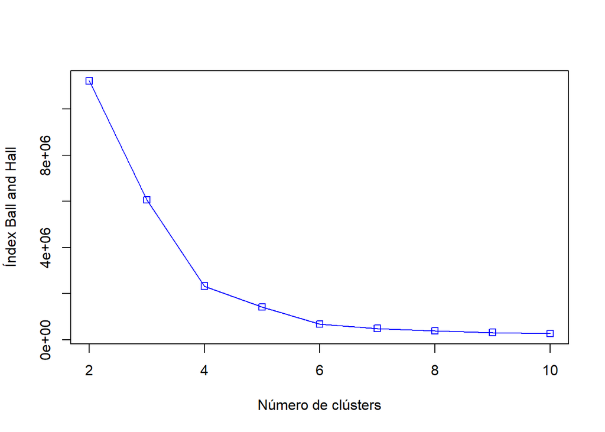

```r
ball_and_hall_index <- function(data, clusters) {
  k <- max(clusters)
  ssw <- sum(cluster.stats(dist(data), clusters)$within.cluster.ss)
  return(ssw / k)
}
k_values <- 2:10
bh_indices <- numeric(length(k_values))
for (i in k_values) {
  clust <- kmeans(x, centers=i)$cluster
  bh_indices[i-1] <- ball_and_hall_index(x, clust)
}
plot(2:10,bh_indices,type="o",col="blue",pch=0,xlab="Número de clústers",ylab="Índex Ball and Hall")
```

La funció ball_and_halls_index calcula l’índex Ball and Hall per a un conjunt de dades i les seves etiquetes de clúster corresponents.

Observem que al voltant de k=5 l’índex comença a estabilitzar-se, això ens indica que anar més enllà de 5 clústers no ens aporta millores al model.

Així doncs, tenint en compte els resultats vistos, podem dir que el nombre de clústers òptims són 2 o 3. Tenint en compte la informació que sabem del conjunt de dades, seleccionarem 3 clústers.

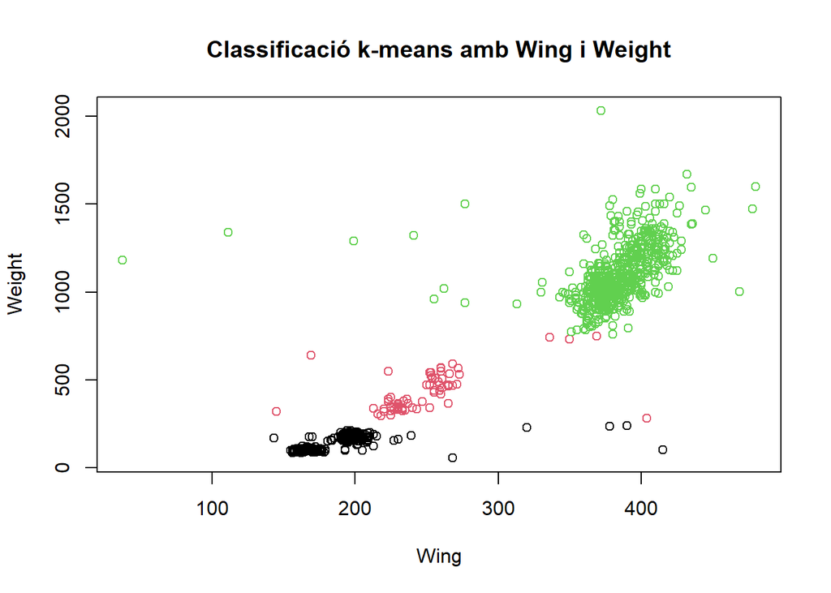

```r
hawks3clusters <- kmeans(x,3)
# Wing i Weight
plot(x[c("Wing", "Weight")], col=hawks3clusters$cluster, main="Classificació k-means amb Wing i Weight")
```

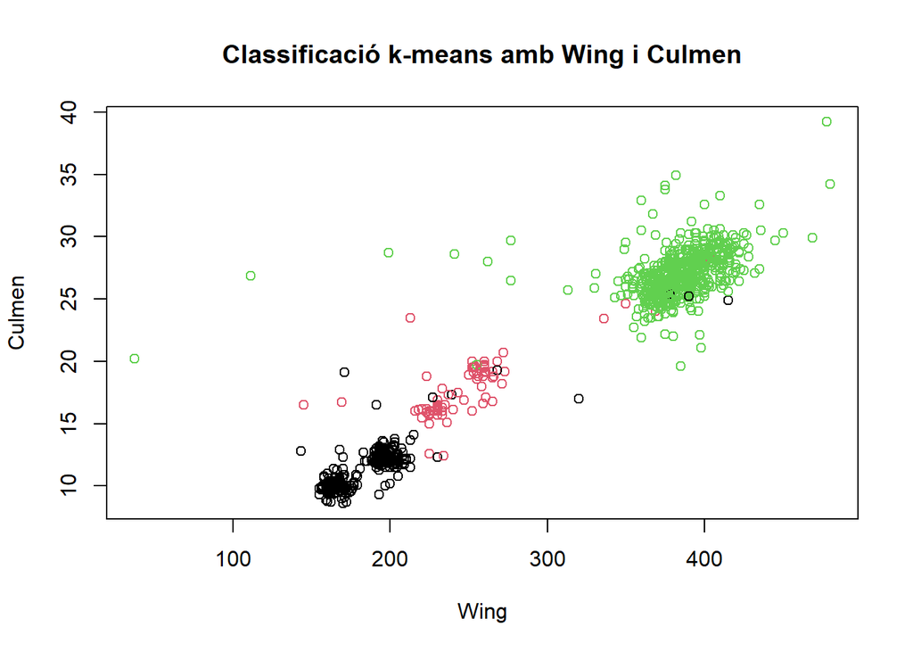

```r
# Wing i Culmen
plot(x[c("Wing", "Culmen")], col=hawks3clusters$cluster, main="Classificació k-means amb Wing i Culmen")
```

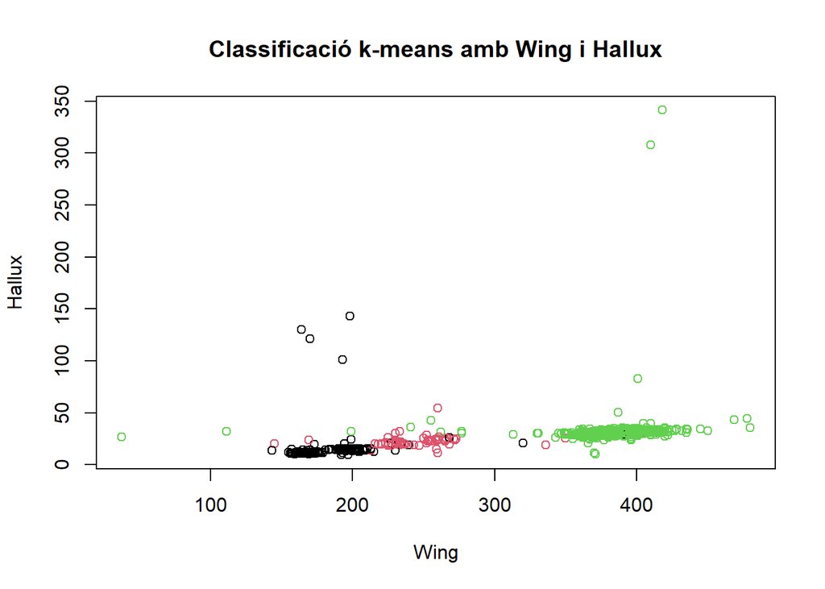

```r
# Wing i Hallux
plot(x[c("Wing", "Hallux")], col=hawks3clusters$cluster, main="Classificació k-means amb Wing i Hallux")
```

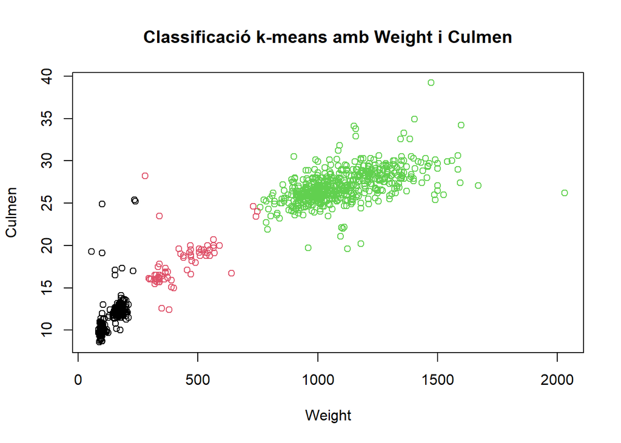

```r
# Weight i Culmen
plot(x[c("Weight", "Culmen")], col=hawks3clusters$cluster, main="Classificació k-means amb Weight i Culmen")
```

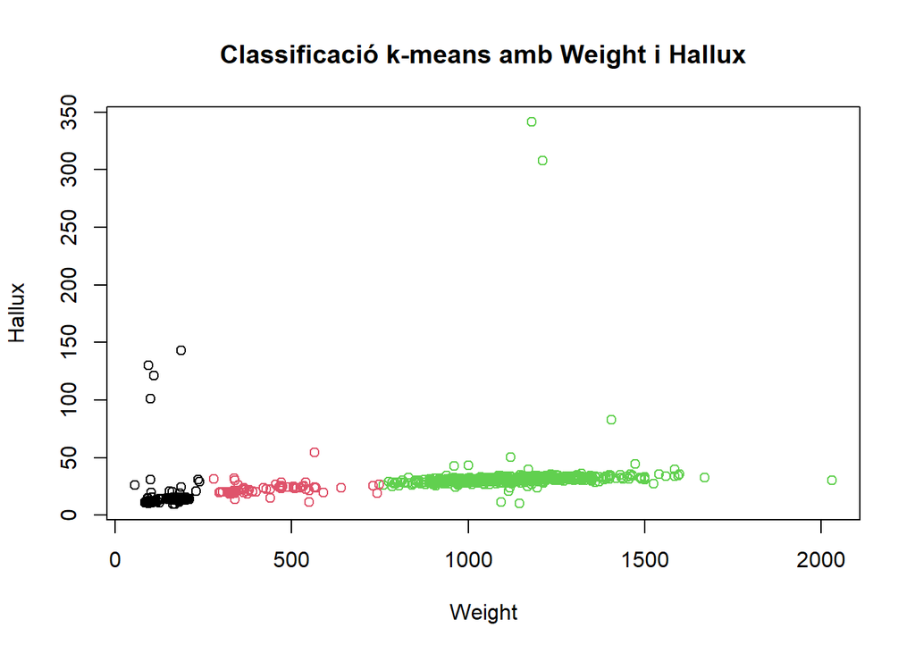

```r
# Weight i Hallux
plot(x[c("Weight", "Hallux")], col=hawks3clusters$cluster, main="Classificació k-means amb Weight i Hallux")
```

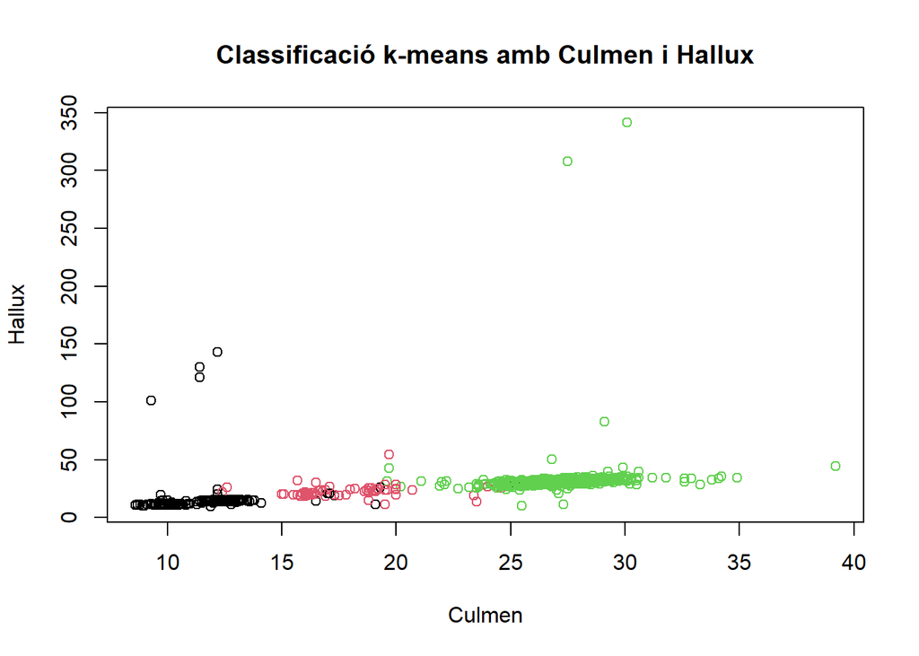

```r
# Culmen i Hallux
plot(x[c("Culmen", "Hallux")], col=hawks3clusters$cluster, main="Classificació k-means amb Culmen i Hallux")
```

Podem veure que hi ha característiques que aporten més informació alhora de diferenciar entre els falcons que d’altres. Per exemple, en la gràfica Weight, Wing es poden veure diferenciats els tres clústers, on en un principi hi tenim falcons lleugers i amb ales petites, en un altre clústers i tenim falcons de ales i pes mig i finalment un clúster amb pes i ales grans.

Comentar també que en el cas de la característica Hallux, els outliners fan que l’escala sigui tan gran que la mostra no sigui representativa. En aquest cas és millor eliminar aquest valors i analitzar de nou.

```r
IQR_Hallux <- IQR(x$Hallux)
Q1_Hallux <- quantile(x$Hallux, 0.25)
Q3_Hallux <- quantile(x$Hallux, 0.75)

cota_inferior <- Q1_Hallux - 1.5 * IQR_Hallux
cota_superior <- Q3_Hallux + 1.5 * IQR_Hallux

x2 <- x[x$Hallux >= cota_inferior & x$Hallux <= cota_superior,]

summary(x2)
```

```
##       Wing           Weight           Culmen          Hallux
##  Min.   : 37.2   Min.   :  56.0   Min.   : 8.60   Min.   : 9.50
##  1st Qu.:203.0   1st Qu.: 185.0   1st Qu.:12.80   1st Qu.:15.07
##  Median :370.0   Median : 970.0   Median :25.50   Median :29.40
##  Mean   :316.2   Mean   : 772.9   Mean   :21.83   Mean   :25.23
##  3rd Qu.:390.0   3rd Qu.:1120.0   3rd Qu.:27.30   3rd Qu.:31.40
##  Max.   :480.0   Max.   :2030.0   Max.   :39.20   Max.   :54.50
```

Per detectar i eliminar els outliners hem fet servir el mètode IQR, que mesura la dispersió estadística que indica la diferència entre el tercer quartil i el primer. A continuació establim les cotes superior i inferior de les nostres mostres i finalment guardem en x2 les mostres que estan dins del conjunt acotat.

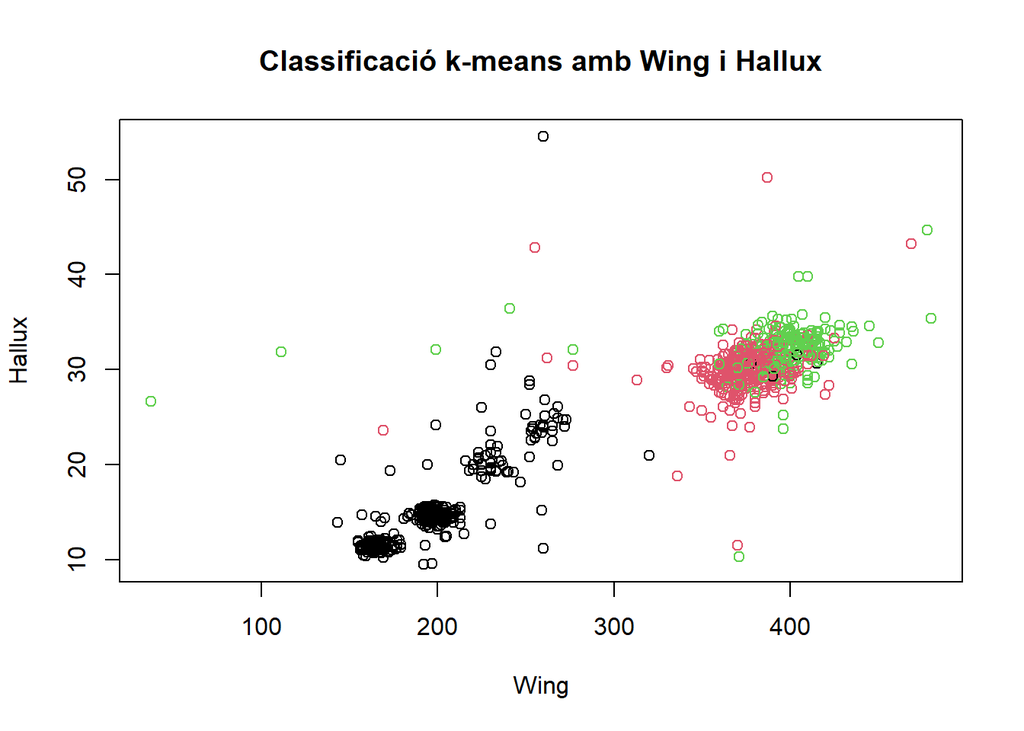

```r
hawks3clusters2 <- kmeans(x2,3)

# Wing i Hallux
plot(x2[c("Wing", "Hallux")], col=hawks3clusters2$cluster, main="Classificació k-means amb Wing i Hallux")
```

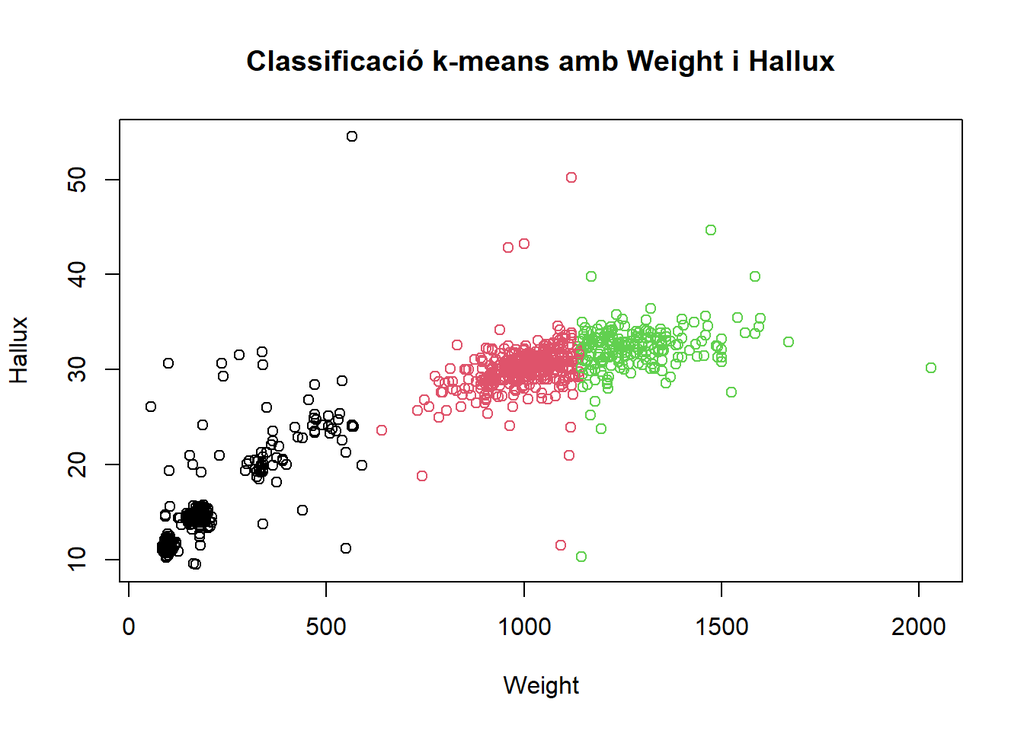

```r
# Weight i Hallux
plot(x2[c("Weight", "Hallux")], col=hawks3clusters2$cluster, main="Classificació k-means amb Weight i Hallux")
```

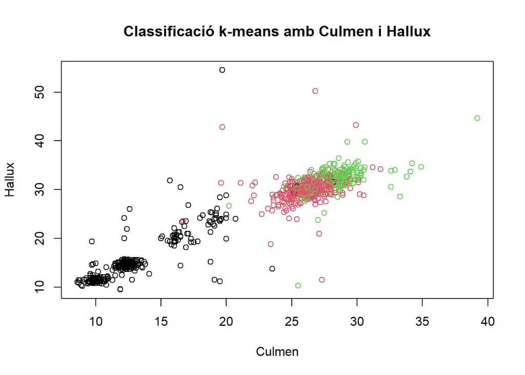

```r
# Culmen i Hallux
plot(x2[c("Culmen", "Hallux")], col=hawks3clusters2$cluster, main="Classificació k-means amb Culmen i Hallux")
```

Podem veure com en el cas de la gràfica Hallux, Weight si que és possible veure els tres clústers diferenciats sense solapament.

## 1.2 Exercici 2

Amb el joc de dades proporcionat realitza un estudi aplicant DBSCAN i OPTICS, similar al de l’exemple 2

### 1.2.1 Resposta 2

Primer de tot instalarem la biblioteca necessària per a la realització de l’exercici

```r
if (!require('dbscan')) install.packages('dbscan'); library('dbscan')
res <- optics(x, minPts = 10)
res
```

```
## OPTICS ordering/clustering for 891 objects.
## Parameters: minPts = 10, eps = 531.584706326283, eps_cl = NA, xi = NA
## Available fields: order, reachdist, coredist, predecessor, minPts, eps,
##                   eps_cl, xi
```

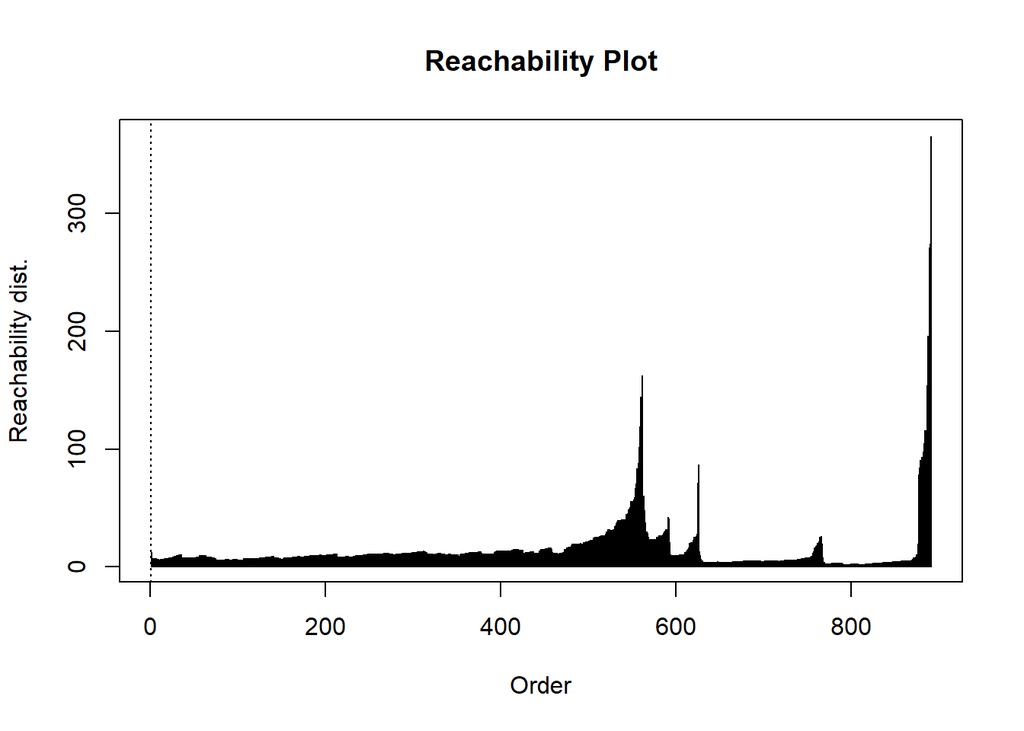

```r
plot(res)
```

En l’eix horitzontal es representa l’ordre en el que les mostres han estat processades per l’algoritme OPTICS. L’eix vertical és el valor mínim entre la distància d’un punt a un altre ja processat i la distància d’aquest punt a la seva *MinPts-éssima* mostra més propera. Les zones amb valors baixos indiquen zones d’alta densitat, és a dir, possibles clústers. En canvi, els pics representen transicions entre zones de diferent densitat.

Si mirem la gràfica podem veure que al principi hi ha una zona de gran densitat, indicant un possible clúster. Al voltant de la posició 600 n’hi hauria un altre i, finalment, en la posició 800 l’últim.

És possible treure una agrupació de la ordenació realitzada per OPTICS establing el paràmetre *eps* en *eps_cl = k*. Aquest paràmetre determina el llindar de distància per a decidir si els punts són veïns i pertanyen al mateix clúster, és a dir, els punts que estan per sota de la linia horitozntal de valor *eps_cl* es consideren clústers, els que estan per sobre, outliners o soroll.

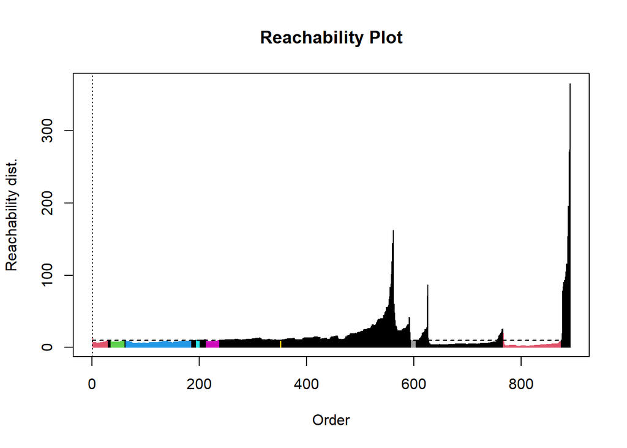

```r
### valor petit de eps_cl
res <- extractDBSCAN(res, eps_cl = 10)
plot(res)
```

Per a un valor de eps_cl igual a 10 podem observar que hi ha 8 clústers diferents i que la majoria de punts es consideren soroll o outliners.

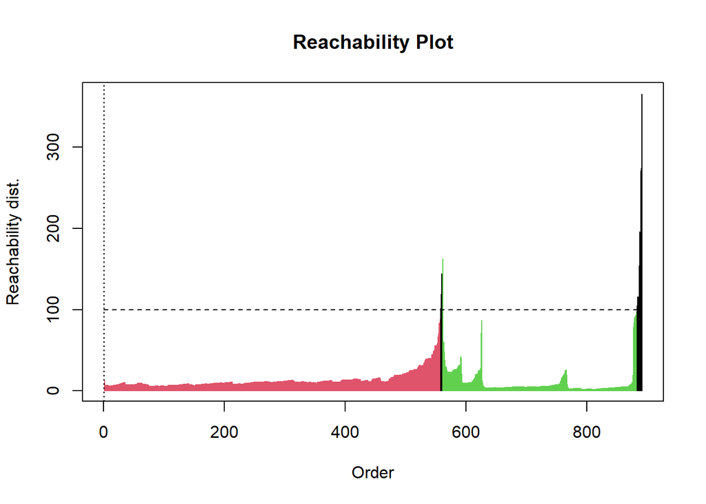

```r
### valor gran de eps_cl
res <- extractDBSCAN(res, eps_cl = 100)
plot(res)
```

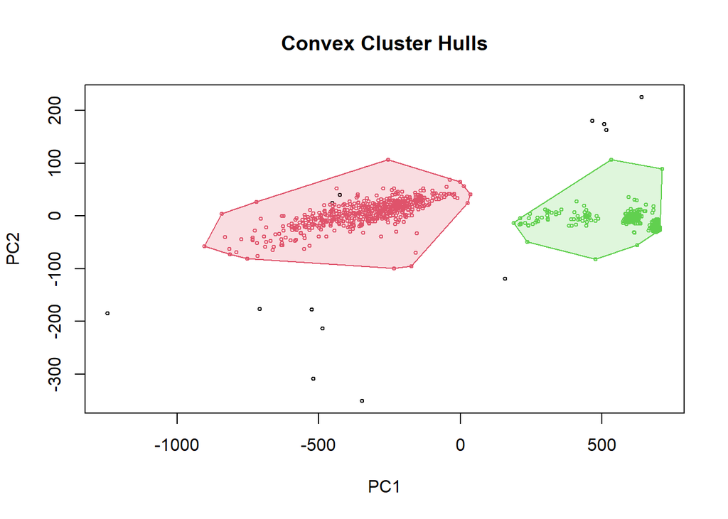

```r
hullplot(x, res)
```

Si fixem un valor més gran, en aquest cas 100. Tindrem dos clústers i menys punts considerats soroll. Hi ha d’haver un equilibri entre el soroll i el mínim valor de clústers, així doncs, el que farem és establir un valor que estigui a l’alçada dels pics que separen els possibles clústers que hem comentat al principi de l’exercici

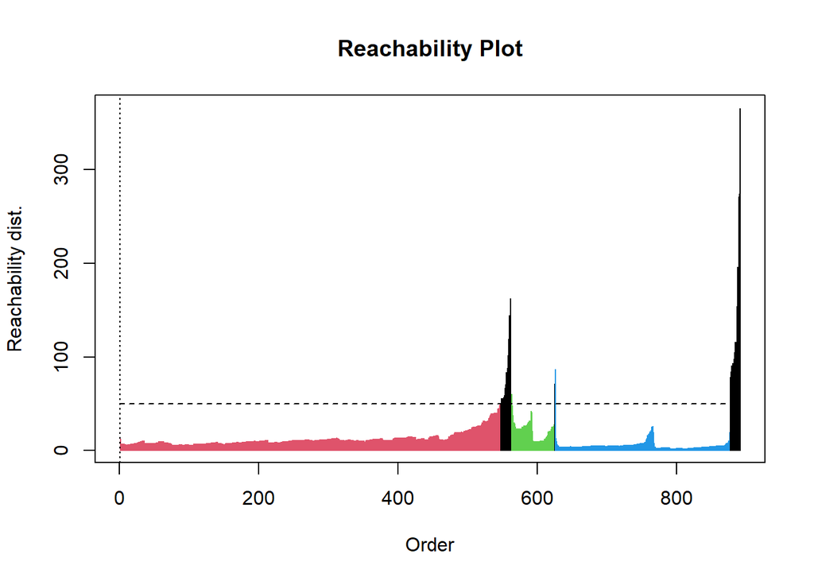

```r
### valor buscat de eps_cl
res <- extractDBSCAN(res, eps_cl = 50)
plot(res)
```

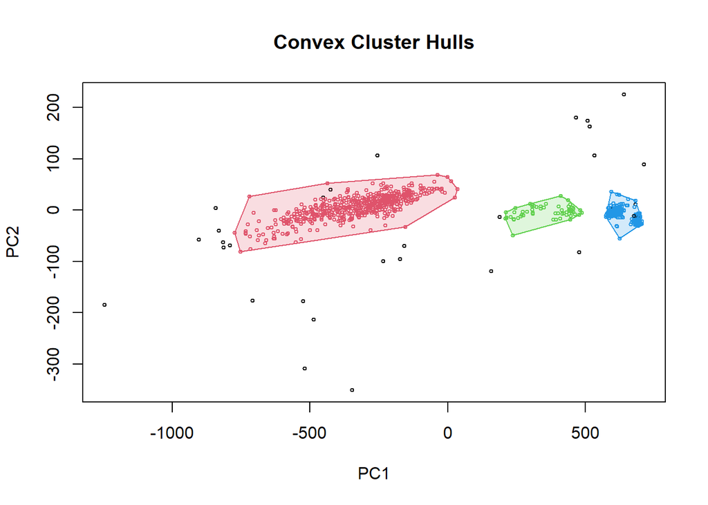

```r
hullplot(x, res)
```

Al fixar el valor en 50, estem fallant els pics i d’aquesta forma es poden veure 3 clústers i es mantenen els valors outliners o extrems.

## 1.3 Exercici 3

Realitza una comparativa dels mètodes *k-means* i *DBSCAN*

### 1.3.1 Resposta 3

Tan el mèotde *k-means* com el *DBSCAN* són mètodes de clústering, però tenen característiques i aplicacions diferents.

1. **Definició del nombre de clústers:**
- k-means: Cal especificar el nombre de clústers a priori.
- DBSCAN: No cal especificar el nombre de clústers, el mètode els determina automàticament en base a la densitat dels punts.
2. **Forma dels clústers:**
- k-means: Assumeix que els clústers són convexos.
- DBSCAN: És capaç d’identificar clústers de qualsevol forma geomètrica, no només circular.
3. **Tractament d’outliners:**
- k-means: És sensible als outliners.
- DBSCAN: Pot identificar els outliners com a punts de soroll, fent així possible que es puguin diferenciar dels punts que pertanyen als clústers.
4. **Complexitat computacional:**
- k-means: En general és més ràpid i adequat per a grans conjunts de dades.
- DBSCAN: Pot ser més lent, especialment si la densitat dels punts varia molt.
5. **Aplicacions:**
- k-means: Funciona millor per dades amb una estructura de clústers uniforme.
- DBSCAN: Funciona millor amb dades amb clústers de densitat variable i formes no convexes.

En aquest treball hem pogut implementar dos mètodes de clústering en un conjunt de dades del món real dels vistos a teoria. Al fer-ho, s’ha pogut comprobar els punts forts i febles de cada mètode així com reflexionar sobre en quins escenaris és millor utilitzar cadascún. Si es té una idea clara de la quanitat de clústers necessaris per a la solució (com és el cas de l’exercici), el mètode de *k-means* és una bona opció. Si l’interés de l’estudi es basa en compendre l’estructura jeràrquica de les dades, és millor utilitzar OPTICS. Finalment, si es necessita un mètode per identificar clústers de formes arbitràries i amb possibles valors outliners, DBSCAN és el més adequat.

Així doncs, la millor opció depèn del tipus de dades i dels objectius específics. En aquest cas ha sigut útil aplicar diferents mètodes i comparar els seus resultats.